# Bài tập: Phân tích phân biệt

Bùi Đức Anh

2024-05-09

#### **Bài 10.2**

```r
library(gap)
data = hla[, 2:8]
library(rpart)
names(data)
```

```
## [1] "y"      "DQR.a1" "DQR.a2" "DQA.a1" "DQA.a2" "DQB.a1" "DQB.a2"
```

```r
tree01 <- rpart(y ~. , data = data)
tree01
```

```
## n= 271
##
## node), split, n, deviance, yval
##       * denotes terminal node
##
##  1) root 271 61.3948300 0.34686350
##    2) DQA.a1< 5.5 207 40.8502400 0.27053140
##      4) DQR.a2< 12.5 110 12.2181800 0.12727270
##        8) DQR.a1>=1.5 87  4.7126440 0.05747126 *
##        9) DQR.a1< 1.5 23  5.4782610 0.39130430
##         18) DQB.a2>=2.5 15  2.9333330 0.26666670 *
##         19) DQB.a2< 2.5 8  1.8750000 0.62500000 *
##      5) DQR.a2>=12.5 97 23.8144300 0.43298970
##       10) DQR.a1< 6.5 35  5.6000000 0.20000000
##         20) DQR.a1>=2.5 15  0.0000000 0.00000000 *
##         21) DQR.a1< 2.5 20  4.5500000 0.35000000 *
##       11) DQR.a1>=6.5 62 15.2419400 0.56451610
##         22) DQA.a2>=3.5 29  6.8275860 0.37931030
##           44) DQR.a2>=15.5 21  3.8095240 0.23809520
##             88) DQR.a2< 21.5 14  0.9285714 0.07142857 *
##             89) DQR.a2>=21.5 7  1.7142860 0.57142860 *
##           45) DQR.a2< 15.5 8  1.5000000 0.75000000 *
##         23) DQA.a2< 3.5 33  6.5454550 0.72727270
##           46) DQR.a1>=21.5 8  1.5000000 0.25000000 *
##           47) DQR.a1< 21.5 25  2.6400000 0.88000000 *
##    3) DQA.a1>=5.5 64 15.4375000 0.59375000
##      6) DQA.a1>=7.5 44 10.6363600 0.40909090
##       12) DQB.a2< 2.5 21  3.8095240 0.23809520 *
##       13) DQB.a2>=2.5 23  5.6521740 0.56521740 *
##      7) DQA.a1< 7.5 20  0.0000000 1.00000000 *
```

```r
printcp(tree01)
```

```
##
## Regression tree:
## rpart(formula = y ~ ., data = data)
##
## Variables actually used in tree construction:
## [1] DQA.a1 DQA.a2 DQB.a2 DQR.a1 DQR.a2
##
## Root node error: 61.395/271 = 0.22655
##
## n= 271
##
##          CP nsplit rel error  xerror     xstd
## 1  0.083184      0   1.00000 1.00809 0.039460
## 2  0.078470      1   0.91682 0.99527 0.053565
## 3  0.078201      2   0.83835 0.98116 0.053229
## 4  0.048416      3   0.76015 0.83710 0.054486
## 5  0.034810      4   0.71173 0.86257 0.060834
## 6  0.033020      6   0.64211 0.85289 0.066378
## 7  0.024726      7   0.60909 0.83933 0.068464
## 8  0.019133      8   0.58436 0.85063 0.069827
## 9  0.019003      9   0.56523 0.85055 0.069912
## 10 0.017102     10   0.54623 0.85634 0.070758
## 11 0.010912     11   0.52912 0.84896 0.070908
## 12 0.010000     12   0.51821 0.84314 0.071595
```

```r
best01 <- tree01$cptable[which.min(tree01$cptable[, "xerror"]), "CP"]
best01
```

```
## [1] 0.04841609
```

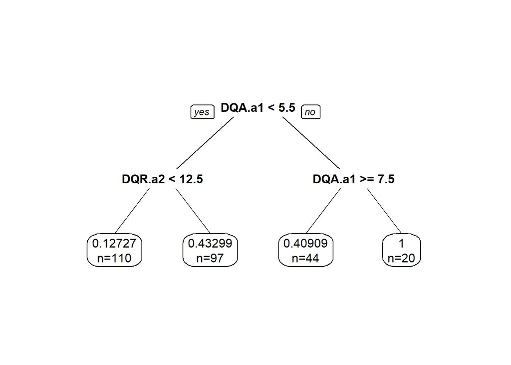

```r
prunned_tree01 <- prune(tree01, cp= best01)
library(rpart.plot)
prp(prunned_tree01,
    faclen = 0,
    extra = 1,
    roundint = F,
    digits = 5)
```

#### **Bài 10.4**

```r
data(iris)
library(MASS)
ld <- lda(Species ~ ., data = iris)
ld$scaling
```

```
##                     LD1         LD2
## Sepal.Length  0.8293776  0.02410215
## Sepal.Width   1.5344731  2.16452123
## Petal.Length -2.2012117 -0.93192121
## Petal.Width  -2.8104603  2.83918785
```

#### **Bài 10.6**

```r
library(kernlab)
data(promotergene)
library(rpart)
tree02 <- rpart(Class ~ ., data = promotergene)
tree02
```

```
## n= 106
##
## node), split, n, loss, yval, (yprob)
##       * denotes terminal node
##
## 1) root 106 53 + (0.50000000 0.50000000)
##   2) V16=t 54 11 + (0.79629630 0.20370370)
##     4) V40=a,t 41  3 + (0.92682927 0.07317073) *
##     5) V40=c,g 13  5 - (0.38461538 0.61538462) *
##   3) V16=a,c,g 52 10 - (0.19230769 0.80769231)
##     6) V18=g 19  9 + (0.52631579 0.47368421) *
##     7) V18=a,c,t 33  0 - (0.00000000 1.00000000) *
```

```r
printcp(tree02)
```

```
##
## Classification tree:
## rpart(formula = Class ~ ., data = promotergene)
##
## Variables actually used in tree construction:
## [1] V16 V18 V40
##
## Root node error: 53/106 = 0.5
##
## n= 106
##
##         CP nsplit rel error  xerror     xstd
## 1 0.603774      0   1.00000 1.26415 0.093679
## 2 0.056604      1   0.39623 0.64151 0.090673
## 3 0.018868      2   0.33962 0.64151 0.090673
## 4 0.010000      3   0.32075 0.56604 0.087506
```

```r
best02 <- tree02$cptable[which.min(tree02$cptable[, "xerror"]), "CP"]
best02
```

```
## [1] 0.01
```

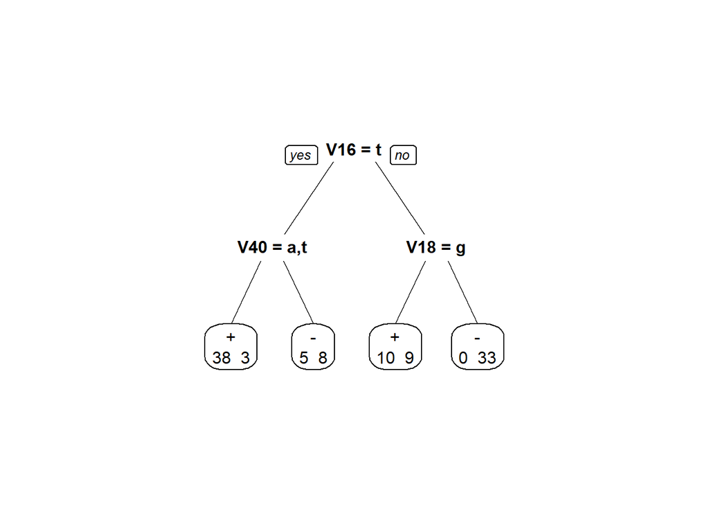

```r
prunned_tree02 <- prune(tree02, cp= best02)

prp(prunned_tree02,
    faclen = 0,
    extra = 1,
    roundint = F,
    digits = 5)
```

#### **Bài 10.7**

```r
library(kernlab)
data(spam)
library(rpart)
tree03 <- rpart(type ~ ., data = spam)
tree03
```

```
## n= 4601
##
## node), split, n, loss, yval, (yprob)
##       * denotes terminal node
##
##  1) root 4601 1813 nonspam (0.60595523 0.39404477)
##    2) charDollar< 0.0555 3471  816 nonspam (0.76490925 0.23509075)
##      4) remove< 0.055 3141  516 nonspam (0.83572111 0.16427889)
##        8) charExclamation< 0.378 2737  275 nonspam (0.89952503 0.10047497) *
##        9) charExclamation>=0.378 404  163 spam (0.40346535 0.59653465)
##         18) capitalTotal< 55.5 182   52 nonspam (0.71428571 0.28571429)
##           36) free< 0.845 161   32 nonspam (0.80124224 0.19875776) *
##           37) free>=0.845 21    1 spam (0.04761905 0.95238095) *
##         19) capitalTotal>=55.5 222   33 spam (0.14864865 0.85135135) *
##      5) remove>=0.055 330   30 spam (0.09090909 0.90909091) *
##    3) charDollar>=0.0555 1130  133 spam (0.11769912 0.88230088)
##      6) hp>=0.4 70    7 nonspam (0.90000000 0.10000000) *
##      7) hp< 0.4 1060   70 spam (0.06603774 0.93396226) *
```

```r
printcp(tree03)
```

```
##
## Classification tree:
## rpart(formula = type ~ ., data = spam)
##
## Variables actually used in tree construction:
## [1] capitalTotal    charDollar      charExclamation free
## [5] hp              remove
##
## Root node error: 1813/4601 = 0.39404
##
## n= 4601
##
##         CP nsplit rel error  xerror     xstd
## 1 0.476558      0   1.00000 1.00000 0.018282
## 2 0.148924      1   0.52344 0.54771 0.015392
## 3 0.043023      2   0.37452 0.45505 0.014352
## 4 0.030888      4   0.28847 0.33149 0.012608
## 5 0.010480      5   0.25758 0.29178 0.011935
## 6 0.010000      6   0.24710 0.27468 0.011624
```

```r
best03 <- tree03$cptable[which.min(tree03$cptable[, "xerror"]), "CP"]
best03
```

```
## [1] 0.01
```

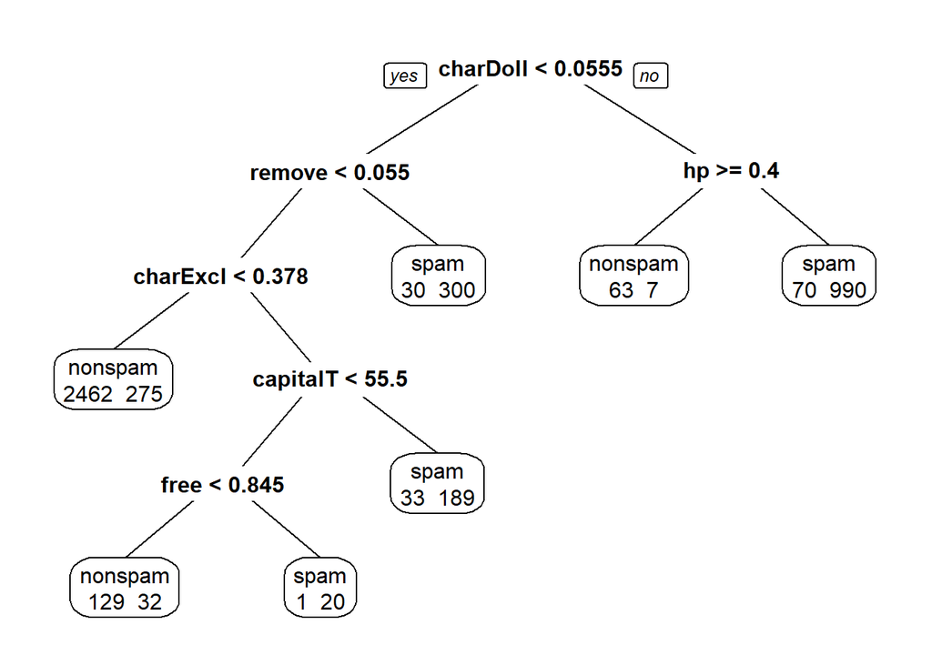

```r
prunned_tree03 <- prune(tree03, cp= best03)

prp(prunned_tree03,
    faclen = 0,
    extra = 1,
    roundint = F,
    digits = 5)
```

#### **Bài 10.12**

```r
library(rpart)
data(stagec)
tree04 <- rpart(pgstat ~ ., data = stagec)
tree04
```

```
## n= 146
##
## node), split, n, deviance, yval
##       * denotes terminal node
##
##  1) root 146 34.027400 0.36986300
##    2) pgtime>=4.45 102 14.166670 0.16666670
##      4) g2< 13.2 61  3.737705 0.06557377
##        8) gleason< 6.5 45  0.000000 0.00000000 *
##        9) gleason>=6.5 16  3.000000 0.25000000 *
##      5) g2>=13.2 41  8.878049 0.31707320
##       10) pgtime>=8.1 13  0.000000 0.00000000 *
##       11) pgtime< 8.1 28  6.964286 0.46428570
##         22) g2>=17.6 12  2.250000 0.25000000 *
##         23) g2< 17.6 16  3.750000 0.62500000 *
##    3) pgtime< 4.45 44  5.886364 0.84090910
##      6) pgtime>=3.05 17  3.529412 0.70588240 *
##      7) pgtime< 3.05 27  1.851852 0.92592590 *
```

```r
printcp(tree04)
```

```
##
## Regression tree:
## rpart(formula = pgstat ~ ., data = stagec)
##
## Variables actually used in tree construction:
## [1] g2      gleason pgtime
##
## Root node error: 34.027/146 = 0.23306
##
## n= 146
##
##         CP nsplit rel error  xerror     xstd
## 1 0.410680      0   1.00000 1.01320 0.045380
## 2 0.050910      1   0.58932 0.67449 0.094103
## 3 0.028339      3   0.48750 0.68234 0.094201
## 4 0.021680      4   0.45916 0.71509 0.096182
## 5 0.014844      5   0.43748 0.71227 0.096144
## 6 0.010000      6   0.42264 0.70857 0.095842
```

```r
best04 <- tree04$cptable[which.min(tree04$cptable[, "xerror"]), "CP"]
best04
```

```
## [1] 0.05091009
```

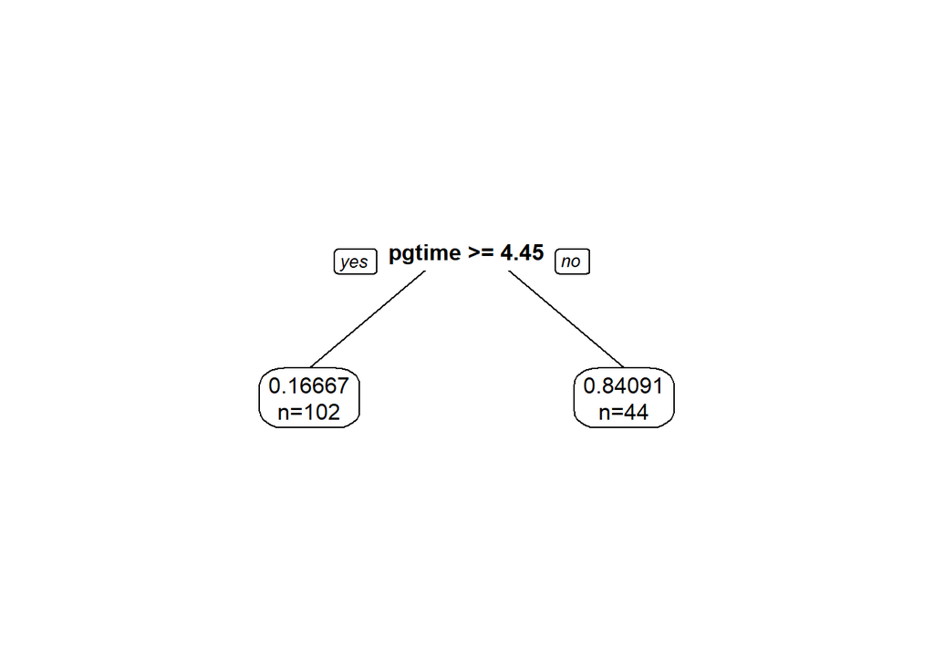

```r
prunned_tree04 <- prune(tree04, cp= best04)

prp(prunned_tree04,
    faclen = 0,
    extra = 1,
    roundint = F,
    digits = 5)
```

#### **Bài 10.13**

```r
library(rpart)
data(kyphosis)
tree05 <- rpart(Kyphosis ~ ., data = kyphosis)
tree05
```

```
## n= 81
##
## node), split, n, loss, yval, (yprob)
##       * denotes terminal node
##
##  1) root 81 17 absent (0.79012346 0.20987654)
##    2) Start>=8.5 62  6 absent (0.90322581 0.09677419)
##      4) Start>=14.5 29  0 absent (1.00000000 0.00000000) *
##      5) Start< 14.5 33  6 absent (0.81818182 0.18181818)
##       10) Age< 55 12  0 absent (1.00000000 0.00000000) *
##       11) Age>=55 21  6 absent (0.71428571 0.28571429)
##         22) Age>=111 14  2 absent (0.85714286 0.14285714) *
##         23) Age< 111 7  3 present (0.42857143 0.57142857) *
##    3) Start< 8.5 19  8 present (0.42105263 0.57894737) *
```

```r
printcp(tree05)
```

```
##
## Classification tree:
## rpart(formula = Kyphosis ~ ., data = kyphosis)
##
## Variables actually used in tree construction:
## [1] Age   Start
##
## Root node error: 17/81 = 0.20988
##
## n= 81
##
##         CP nsplit rel error  xerror    xstd
## 1 0.176471      0   1.00000 1.00000 0.21559
## 2 0.019608      1   0.82353 0.94118 0.21078
## 3 0.010000      4   0.76471 0.94118 0.21078
```

```r
best05 <- tree05$cptable[which.min(tree05$cptable[, "xerror"]), "CP"]
best05
```

```
## [1] 0.01960784
```

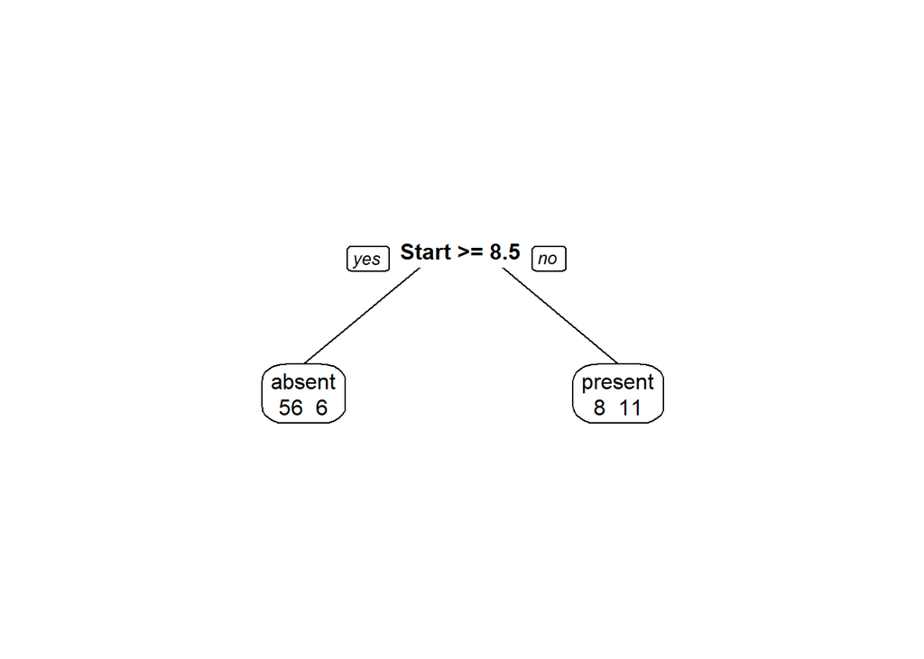

```r
prunned_tree05 <- prune(tree05, cp= best05)

prp(prunned_tree05,
    faclen = 0,
    extra = 1,
    roundint = F,
    digits = 5)
```

```r
library(nnet)
kyphosis$class <- as.factor(kyphosis$Kyphosis)
kyphosis$rClass <- relevel(kyphosis$Kyphosis, ref = 2)
kyphosislogit <- multinom(rClass ~ ., data = kyphosis)
print(ws <- summary(kyphosislogit), digits = 4)
```

```
## Call:
## multinom(formula = rClass ~ ., data = kyphosis)
##
## Coefficients:
##                     Values Std. Err.
## (Intercept)       7.771689  166.4184
## Kyphosispresent -12.300162   73.9920
## Age               0.006211    0.9895
## Number            0.454269   28.6584
## Start             0.245392   10.1257
## classpresent    -12.300162   73.9920
##
## Residual Deviance: 0.001003053
## AIC: 10.001
```

Kiểm định các biến có ý nghĩa trong mô hình

```r
tratio <- ws$coefficients/ws$standard.errors
print(2 * (1 - pt(abs(tratio), df = ws$edf)), digits = 4)
```

```
##     (Intercept) Kyphosispresent             Age          Number           Start
##          0.9646          0.8745          0.9952          0.9880          0.9816
##    classpresent
##          0.8745
```

```r
ws$fitted.values
```

```
##            [,1]
## 1  9.999797e-01
## 2  9.999987e-01
## 3  2.283920e-06
## 4  9.999664e-01
## 5  9.999983e-01
## 6  9.999967e-01
## 7  9.999982e-01
## 8  9.999983e-01
## 9  9.999983e-01
## 10 2.056549e-05
## 11 2.460558e-05
## 12 9.999992e-01
## 13 9.999762e-01
## 14 9.999964e-01
```

[output cut: 67 more lines]

Cây hồi quy: Trực quan hơn, quy trình ra quyết định dễ dàng, dễ theo dõi. Tương đói dễ sủ dụng với các hàm tích hợp trong thư viện R. Việc điều chỉnh và cắt tỉa đòi hỏi một số thử nghiệm  
Hồi quy logistic: Ít trực quan hơn, đặc biệt là giải thích hệ số, cần có một số kiến thức về thống kê và cách hoạt động của hồi quy logistic. Tương đối dễ sử dụng tỏng thư viện R. Việc giải thích có thể khó khăn hơn cây hồi quy.

#### **Bài 10.14**

```r
library(TH.data)
data(mammoexp)
tree06 <- rpart(ME ~ ., data = mammoexp)
tree06
```

```
## n= 412
##
## node), split, n, loss, yval, (yprob)
##       * denotes terminal node
##
##   1) root 412 178 Never (0.56796117 0.25242718 0.17961165)
##     2) SYMPT=Strongly Agree,Agree 113  18 Never (0.84070796 0.05309735 0.10619469) *
##     3) SYMPT=Disagree,Strongly Disagree 299 160 Never (0.46488294 0.32775920 0.20735786)
##       6) PB>=9.5 51  16 Never (0.68627451 0.13725490 0.17647059) *
##       7) PB< 9.5 248 144 Never (0.41935484 0.36693548 0.21370968)
##        14) HIST=No 216 117 Never (0.45833333 0.33796296 0.20370370)
##          28) DECT=Not likely,Somewhat likely 46  17 Never (0.63043478 0.13043478 0.23913043) *
##          29) DECT=Very likely 170 100 Never (0.41176471 0.39411765 0.19411765)
##            58) BSE=No 15   3 Never (0.80000000 0.20000000 0.00000000) *
##            59) BSE=Yes 155  91 Within a Year (0.37419355 0.41290323 0.21290323)
##             118) SYMPT=Strongly Agree,Agree,Disagree 69  38 Never (0.44927536 0.37681159 0.17391304) *
##             119) SYMPT=Strongly Disagree 86  48 Within a Year (0.31395349 0.44186047 0.24418605) *
##        15) HIST=Yes 32  14 Within a Year (0.15625000 0.56250000 0.28125000) *
```

```r
printcp(tree06)
```

```
##
## Classification tree:
## rpart(formula = ME ~ ., data = mammoexp)
##
## Variables actually used in tree construction:
## [1] BSE   DECT  HIST  PB    SYMPT
##
## Root node error: 178/412 = 0.43204
##
## n= 412
##
##         CP nsplit rel error  xerror     xstd
## 1 0.024345      0   1.00000 1.00000 0.056487
## 2 0.016854      3   0.92697 1.01685 0.056595
## 3 0.010000      6   0.86517 0.99438 0.056448
```

```r
best06 <- tree06$cptable[which.min(tree06$cptable[, "xerror"]), "CP"]
best06
```

```
## [1] 0.01
```

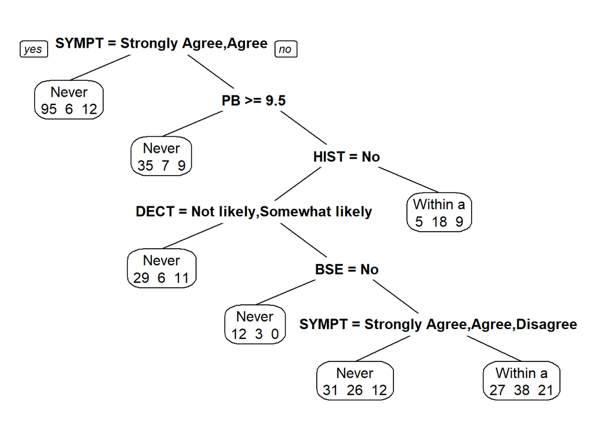

```r
prunned_tree06 <- prune(tree06, cp= best06)

prp(prunned_tree06,
    faclen = 0,
    extra = 1,
    roundint = F,
    digits = 5)
```

#### **Bài 10.16**

```r
library(MASS)
data(mtcars)
tree07 <- rpart(mpg ~ ., data = mtcars)
tree07
```

```
## n= 32
##
## node), split, n, deviance, yval
##       * denotes terminal node
##
## 1) root 32 1126.04700 20.09062
##   2) cyl>=5 21  198.47240 16.64762
##     4) hp>=192.5 7   28.82857 13.41429 *
##     5) hp< 192.5 14   59.87214 18.26429 *
##   3) cyl< 5 11  203.38550 26.66364 *
```

```r
printcp(tree07)
```

```
##
## Regression tree:
## rpart(formula = mpg ~ ., data = mtcars)
##
## Variables actually used in tree construction:
## [1] cyl hp
##
## Root node error: 1126/32 = 35.189
##
## n= 32
##
##         CP nsplit rel error  xerror    xstd
## 1 0.643125      0   1.00000 1.10120 0.25378
## 2 0.097484      1   0.35687 0.63397 0.17141
## 3 0.010000      2   0.25939 0.48506 0.12437
```

```r
best07 <- tree07$cptable[which.min(tree07$cptable[, "xerror"]), "CP"]
best07
```

```
## [1] 0.01
```

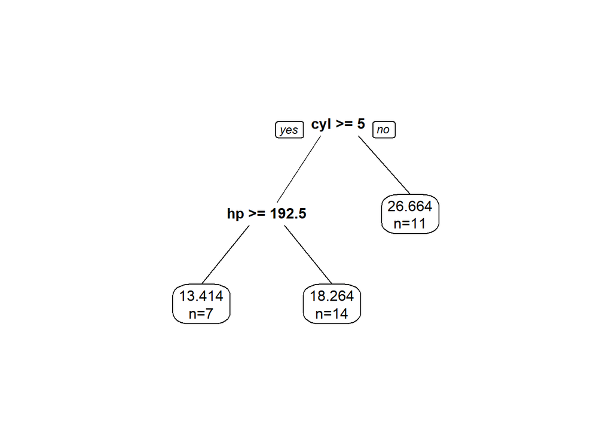

```r
prunned_tree07 <- prune(tree07, cp= best07)

prp(prunned_tree07,
    faclen = 0,
    extra = 1,
    roundint = F,
    digits = 5)
```